# STATS 306 final project

# Introduction

Accidents on the road present danger to all vehicles. Ideally, we want the number of reported accidents to be 0, however realistically, there are still many factors that may cause an unexpected crash. To reduce the number of reported accidents, we must analyze the various factors that cause these accidents to prevent them in the future.

The City of Chicago, being a big city, makes it vulnerable to accidents. They also make accident data available via the [Chicago Data Portal - Traffic Crashes](https://data.cityofchicago.org/Transportation/Traffic-Crashes-Crashes/85ca-t3if) resource. In this report we focus on 2019 records from the dataset in order to analyze:

- variables reported about accidents
- causes of accidents
- potential factors that increase the likelihood of accidents, injuries, and deaths

Specific questions that were explored by our group follow.

## Asking questions about the accident data

1. "How are weather conditions related to the number of accidents?" - Shriya Goel (shriyag)
2. "Which vehicle brands and models were most involved in accidents?" - Alex Choi (alexchoi)
3. "How many and what type of crashes occurred each month?" - Deeksha Gollamudi (dxg)
4. "What can we learn about accidents and fatalities?" - Zhou Jiang (bbjiang)

By exploring these questions, we can come to some understanding of what factors are likely to cause the highest number of crashes.

All team members contributed equally to this project.

# Package loading, data import, data tidying

## R packages loaded for this project

- `tidyverse` - data science utilities, used here for modifying and graphing
- `repr` - string representations of objects, used here for configuring graph settings
- `ggmap` - retrieve map tiles for building maps, used here to map accident locations
- `tmaptools` - tools for mapping spatial data, used here to map accident locations
- `viridisLite` - graphing utilities, used here for a bar graph
- `viridis` - graphing utilities, used here for a bar graph
- `hrbrthemes` - themes for ggplot, used here for a bar graph

Usage of `ggmap` requires the following citation:

> D. Kahle and H. Wickham. ggmap: Spatial Visualization with ggplot2. The R Journal, 5(1), 144-161. URL http://journal.r-project.org/archive/2013-1/kahle-wickham.pdf

```r
suppressMessages(library(tidyverse))
options(dplyr.summarise.inform=F)

library("repr")
options(repr.plot.width = 12, repr.plot.height = 10)

suppressMessages(library("ggmap"))
suppressMessages(library("tmaptools"))

library(viridisLite)
library(viridis)
suppressMessages(library(hrbrthemes))
```

# Dataset import

The following `read_csv()` instruction imports the 2019 traffic crash dataset. Fields that we will be analyzing, and their descriptions, include:

- `CRASH_DATE` - Date and time of crash as entered by the reporting officer
- `CRASH_RECORD_ID` - This number can be used to link to the same crash in the Vehicles and People datasets. This number also serves as a unique ID in this dataset
- `POSTED_SPEED_LIMIT` - Posted speed limit, as determined by reporting officer
- `WEATHER_CONDITION` - Weather condition at time of crash, as determined by reporting officer
- `LIGHTING_CONDITION` - Light condition at time of crash, as determined by reporting officer
- `ROADWAY_SURFACE_COND` - Road surface condition, as determined by reporting officer
- `ROAD_DEFECT` - Road defects, as determined by reporting officer
- `CRASH_TYPE` - A general severity classification for the crash. Can be either Injury and/or Tow Due to Crash or No Injury / Drive Away
- `PRIM_CONTRIBUTORY_CAUSE` - The factor which was most significant in causing the crash, as determined by officer judgment
- `INJURIES_TOTAL` - Total persons sustaining fatal, incapacitating, non-incapacitating, and possible injuries as determined by the reporting officer
- `INJURIES_FATAL` - Total persons sustaining fatal injuries in the crash
- `CRASH_HOUR` - The hour of the day component of CRASH_DATE
- `CRASH_DAY_OF_WEEK` - The day of the week component of CRASH_DATE (Sunday=1)
- `CRASH_MONTH` - The month component of CRASH_DATE
- `LATITUDE` - The latitude of the crash location, as determined by reporting officer, as derived from the reported address of crash
- `LONGITUDE` - The longitude of the crash location, as determined by reporting officer, as derived from the reported address of crash
- `LOCATION` - The crash location, as determined by reporting officer, as derived from the reported address of crash, in a column type that allows for mapping and other geographic analysis in the data portal software

```r
suppressWarnings(suppressMessages(traffic <- read_csv("chicagotraffic2019.csv")))
```

To answer questions related to vehicle make and model, we decided to incorporate the [Vehicles dataset](https://data.cityofchicago.org/Transportation/Traffic-Crashes-Vehicles/68nd-jvt3) as well, for analysis alongside the crash data. The following `read_csv()` instruction imports it. Fields that we will be analyzing, and their descriptions, include:

- `MAKE` - The make (brand) of the vehicle, if relevant
- `MODEL` - The model of the vehicle, if relevant

```r
suppressWarnings(suppressMessages(vehicle <- read_csv("Traffic_Crashes_-_Vehicles.csv")))
```

## Data tidying

The 2019 traffic crash dataset is already tidy, because:

1. Each variable has its own column
2. Each observation has its own row
3. Each value has its own cell

# Question 1: How are Weather Conditions Related to the Number of Accidents?

Chicago is a city that experiences all four seasons. The weather for each of these seasons presents its own danger. For instance, spring being heavy rain and winter brings ice and snow which causes some dangrous road conditions. Since weather is unpredictable, it is important to analyze what specific weather conditions are likely to cause the most accidents. From the Chicago dataset we can understand which weather is presents the most danger and find possible ways to prevent these dangers not only on the Chicago roads but expand our analysis to other big cities. **What we are analyzing in this section** * What weather conditions cause the most accidents? * Are there more accidents at night vs. daylight? * Does the weather cause different road conditions that cause more accidents?

## Analyze and plot the number of car accidents based on weather conditions

We can start the analysis with analyzing the total number of car accidents that occur during a specific weather condition.

```r
crash_weather_conditions<-traffic %>% filter(WEATHER_CONDITION!="UNKNOWN") %>%
            group_by(WEATHER_CONDITION) %>%
            mutate(NUM_CRASH_ACCIDENTS = n()) %>% select(WEATHER_CONDITION,NUM_CRASH_ACCIDENTS) %>%
            print()
```

```
# A tibble: 112,804 x 2
# Groups:   WEATHER_CONDITION [10]
   WEATHER_CONDITION NUM_CRASH_ACCIDENTS
   <chr>                           <int>
 1 CLEAR                           91594
 2 CLEAR                           91594
 3 CLEAR                           91594
 4 CLEAR                           91594
 5 CLEAR                           91594
 6 CLEAR                           91594
 7 CLEAR                           91594
 8 CLEAR                           91594
 9 CLEAR                           91594
10 CLEAR                           91594
# … with 112,794 more rows
```

```r
total_accidents<-traffic%>% nrow()
percent_crashes_weather_conditions <- crash_weather_conditions %>%
                                mutate(percent_weather_condition_accidents = NUM_CRASH_ACCIDENTS/total_accidents) %>%
                                print()
```

```
# A tibble: 112,804 x 3
# Groups:   WEATHER_CONDITION [10]
   WEATHER_CONDITION NUM_CRASH_ACCIDENTS percent_weather_condition_accidents
   <chr>                           <int>                               <dbl>
 1 CLEAR                           91594                               0.778
 2 CLEAR                           91594                               0.778
 3 CLEAR                           91594                               0.778
 4 CLEAR                           91594                               0.778
 5 CLEAR                           91594                               0.778
 6 CLEAR                           91594                               0.778
 7 CLEAR                           91594                               0.778
 8 CLEAR                           91594                               0.778
 9 CLEAR                           91594                               0.778
10 CLEAR                           91594                               0.778
# … with 112,794 more rows
```

Now we will display the data with a pie chart and bar graph to analyze which weather condition causes the most accidents.

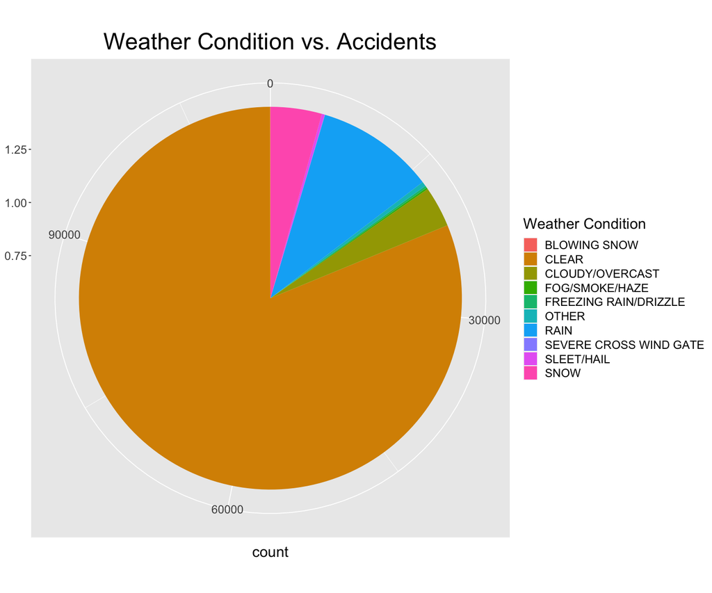

```r
bar <- ggplot(data = percent_crashes_weather_conditions) + geom_bar(mapping = aes(x = 1, fill = WEATHER_CONDITION)) +
            xlab("Weather Condition")+ ggtitle("Weather Condition vs. Accidents") +
            labs(fill = "Weather Condition")
bar + labs(x=NULL) + coord_polar(theta = "y") +
    theme(plot.title = element_text(hjust = 0.5, size = 28),
        legend.title = element_text(size = 18),
        legend.text = element_text(size = 14),
        axis.text = element_text(size=14),
        axis.title.x = element_text(size=18),
        axis.title.y = element_text(size=18))
```

The pie chart displays that the most accidents were caused in clear weather. Before we make a conclusion, let's analyze this data using a bar graph.

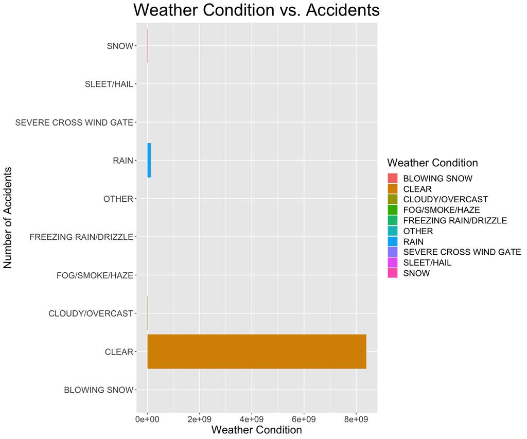

```r
ggplot(data = crash_weather_conditions) +
            geom_bar(mapping = aes(x = WEATHER_CONDITION, y=NUM_CRASH_ACCIDENTS,
                                   fill = WEATHER_CONDITION),stat = "identity") +
            coord_flip() + xlab("Number of Accidents") + ylab("Weather Condition") +
            ggtitle("Weather Condition vs. Accidents") + labs(fill = "Weather Condition") +
        theme(plot.title = element_text(hjust = 0.5, size = 28),
        legend.title = element_text(size = 18),
        legend.text = element_text(size = 14),
        axis.text = element_text(size=14),
        axis.title.x = element_text(size=18),
        axis.title.y = element_text(size=18))
```

From both the pie chart and bar graph (more distinctly shown from the bar graph), the most accidents were caused when the weather was clear. This is significanly higher than the other weather conditions. This is interesting because clear weather does not always present a lot of danger on the road. However, there may be other weather related accidents such as possible road defects.

## Analyze and plot accidents based on road defects

While the weather condition data did not present any dangers that may lead to accidents, we can analyze the various road defects to see if those led to the majority of the crashes.

```r
crash_road_defects<-traffic%>%filter(ROAD_DEFECT!="UNKNOWN" & WEATHER_CONDITION!="UNKNOWN" & ROAD_DEFECT!="NO DEFECTS")%>%
                    group_by(ROAD_DEFECT, WEATHER_CONDITION) %>%
                    summarize(NUM_ACCIDENTS = n()) %>% arrange(desc(NUM_ACCIDENTS)) %>%
                    print
```

```
# A tibble: 35 x 3
# Groups:   ROAD_DEFECT [5]
   ROAD_DEFECT       WEATHER_CONDITION NUM_ACCIDENTS
   <chr>             <chr>                     <int>
 1 RUT, HOLES        CLEAR                      1126
 2 OTHER             CLEAR                       438
 3 WORN SURFACE      CLEAR                       274
 4 SHOULDER DEFECT   CLEAR                       196
 5 RUT, HOLES        RAIN                        170
 6 DEBRIS ON ROADWAY CLEAR                        74
 7 OTHER             RAIN                         65
 8 RUT, HOLES        SNOW                         58
 9 RUT, HOLES        CLOUDY/OVERCAST              48
10 OTHER             SNOW                         47
# … with 25 more rows
```

Let's plot the data and see what the bar graph displays

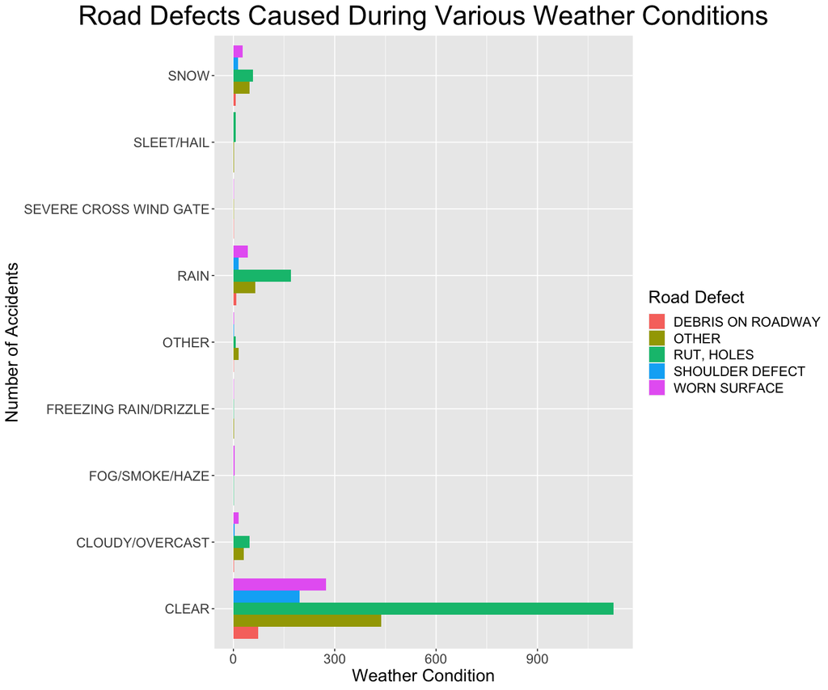

```r
ggplot(data = crash_road_defects) +
    geom_bar(mapping = aes(x = WEATHER_CONDITION, y = NUM_ACCIDENTS, fill = ROAD_DEFECT), stat = "identity",
             position = "dodge") +
    coord_flip() + xlab("Number of Accidents") + ylab("Weather Condition") + labs(fill = "Road Defect") +
    ggtitle("Road Defects Caused During Various Weather Conditions") +
    theme(plot.title = element_text(hjust = 0.5, size = 28),
        legend.title = element_text(size = 18),
        legend.text = element_text(size = 14),
        axis.text = element_text(size=14),
        axis.title.x = element_text(size=18),
        axis.title.y = element_text(size=18))
```

The bar graph groups the road defects for various weather conditions and displays the number of accidents based on that. As we determined above, the most accidents were caused during clear weather. This was informative because presumely clear weather should result in the least amount of accidents. However, from this graph, we see that there were many road defects, prominently rut and holes, on the roads that may have caused these accidents. This observation from the bar graph shows the possibily of other weather conditions causing temporary/permanent road defects and leading to accidents in clear weather.

## Analyze and plot the affects of road surface condition

Various road defects were shown to cause accidents, now we can analyze the road surface condition and see what insight it presents.

```r
crashes_road_condition <- traffic %>% filter(ROADWAY_SURFACE_COND != "UNKNOWN" & WEATHER_CONDITION != "UNKNOWN") %>%
                                            group_by(ROADWAY_SURFACE_COND, WEATHER_CONDITION) %>%
                                            mutate(num_surface_cond_accidents = n()) %>%
                                            arrange(desc(num_surface_cond_accidents)) %>%
                                            select(WEATHER_CONDITION, ROADWAY_SURFACE_COND,
                                                   num_surface_cond_accidents) %>%
                                            print()
```

```
# A tibble: 109,514 x 3
# Groups:   ROADWAY_SURFACE_COND, WEATHER_CONDITION [50]
   WEATHER_CONDITION ROADWAY_SURFACE_COND num_surface_cond_accidents
   <chr>             <chr>                                     <int>
 1 CLEAR             DRY                                       82768
 2 CLEAR             DRY                                       82768
 3 CLEAR             DRY                                       82768
 4 CLEAR             DRY                                       82768
 5 CLEAR             DRY                                       82768
 6 CLEAR             DRY                                       82768
 7 CLEAR             DRY                                       82768
 8 CLEAR             DRY                                       82768
 9 CLEAR             DRY                                       82768
10 CLEAR             DRY                                       82768
# … with 109,504 more rows
```

```r
percent_accidents <- crashes_road_condition %>%
    mutate(percent_surface_cond_accidents = num_surface_cond_accidents/total_accidents) %>%
    print()
```

```
# A tibble: 109,514 x 4
# Groups:   ROADWAY_SURFACE_COND, WEATHER_CONDITION [50]
   WEATHER_CONDITION ROADWAY_SURFACE_C… num_surface_cond_a… percent_surface_con…
   <chr>             <chr>                            <int>                <dbl>
 1 CLEAR             DRY                              82768                0.703
 2 CLEAR             DRY                              82768                0.703
 3 CLEAR             DRY                              82768                0.703
 4 CLEAR             DRY                              82768                0.703
 5 CLEAR             DRY                              82768                0.703
 6 CLEAR             DRY                              82768                0.703
 7 CLEAR             DRY                              82768                0.703
 8 CLEAR             DRY                              82768                0.703
 9 CLEAR             DRY                              82768                0.703
10 CLEAR             DRY                              82768                0.703
# … with 109,504 more rows
```

Now let's plot the data and see what the pie chart presents

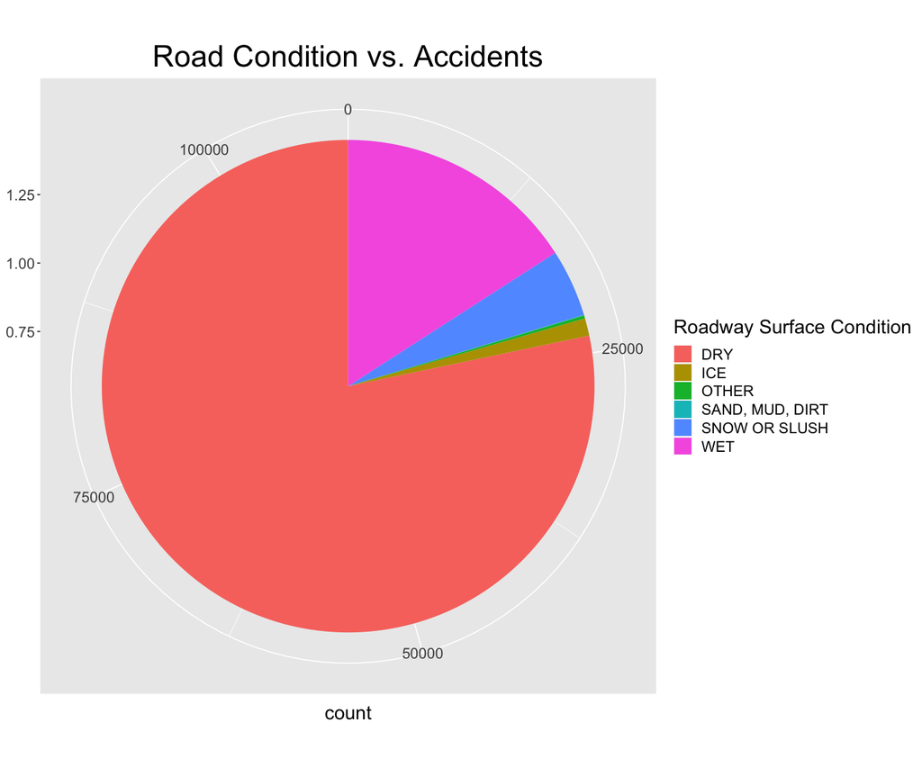

```r
bar <- ggplot(data = percent_accidents) + geom_bar(mapping = aes(x = 1, fill = ROADWAY_SURFACE_COND)) +
        xlab("Roadway Surface Condition")+ ggtitle("Road Condition vs. Accidents")+
        labs(fill = "Roadway Surface Condition")
bar + labs(x=NULL) + coord_polar(theta = "y") +
   theme(plot.title = element_text(hjust = 0.5, size = 28),
        legend.title = element_text(size = 18),
        legend.text = element_text(size = 14),
        axis.text = element_text(size=14),
        axis.title.x = element_text(size=18),
        axis.title.y = element_text(size=18))
```

From the pie chart, we see that most accidents happen when the road is dry. This is interesting and it makes us think about the possible road defects when the road is dry which may be the reason for the crashes.

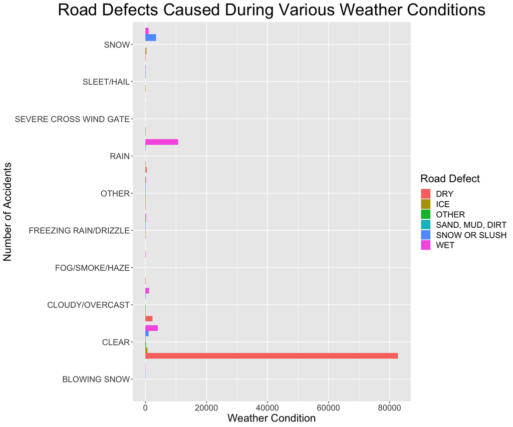

```r
ggplot(data = crashes_road_condition) +
    geom_bar(mapping = aes(x = WEATHER_CONDITION, y = num_surface_cond_accidents, fill = ROADWAY_SURFACE_COND), stat = "identity", position = "dodge") +
    coord_flip() + xlab("Number of Accidents") + ylab("Weather Condition") + labs(fill = "Road Defect") +
    ggtitle("Road Defects Caused During Various Weather Conditions") +
    theme(plot.title = element_text(hjust = 0.5, size = 28),
        legend.title = element_text(size = 18),
        legend.text = element_text(size = 14),
        axis.text = element_text(size=14),
        axis.title.x = element_text(size=18),
        axis.title.y = element_text(size=18))
```

Clear weather still causes the most accidents but also when the road is dry. However, aside from the dry road conditions, wet road conditions are also likely to cause a lot of accidents too. Wet road conditions make it more dangerous to drive and can cause loss of control of the vehicle.

## Analyze and plot the affects of a specific lighting condition

Let's analyze the different lighting condition and see what lighting presents itself as the most danger.

```r
crashes_lighting <- traffic %>% filter(LIGHTING_CONDITION != "UNKNOWN" & WEATHER_CONDITION!="UNKNOWN") %>%
                                        group_by(LIGHTING_CONDITION, WEATHER_CONDITION,CRASH_HOUR)%>%
                                        summarize(NUM_ACCIDENTS = n()) %>% arrange(desc(NUM_ACCIDENTS)) %>%
                                        print
```

```
# A tibble: 691 x 4
# Groups:   LIGHTING_CONDITION, WEATHER_CONDITION [48]
   LIGHTING_CONDITION WEATHER_CONDITION CRASH_HOUR NUM_ACCIDENTS
   <chr>              <chr>                  <dbl>         <int>
 1 DAYLIGHT           CLEAR                     15          6856
 2 DAYLIGHT           CLEAR                     16          6304
 3 DAYLIGHT           CLEAR                     14          6032
 4 DAYLIGHT           CLEAR                     13          5439
 5 DAYLIGHT           CLEAR                     12          5204
 6 DAYLIGHT           CLEAR                     17          5087
 7 DAYLIGHT           CLEAR                      8          4950
 8 DAYLIGHT           CLEAR                     11          4556
 9 DAYLIGHT           CLEAR                     10          4179
10 DAYLIGHT           CLEAR                      9          4136
# … with 681 more rows
```

Now, let's plot the number of accidents for various weather conditions and compare them for different times during the day (different lighting conditions).

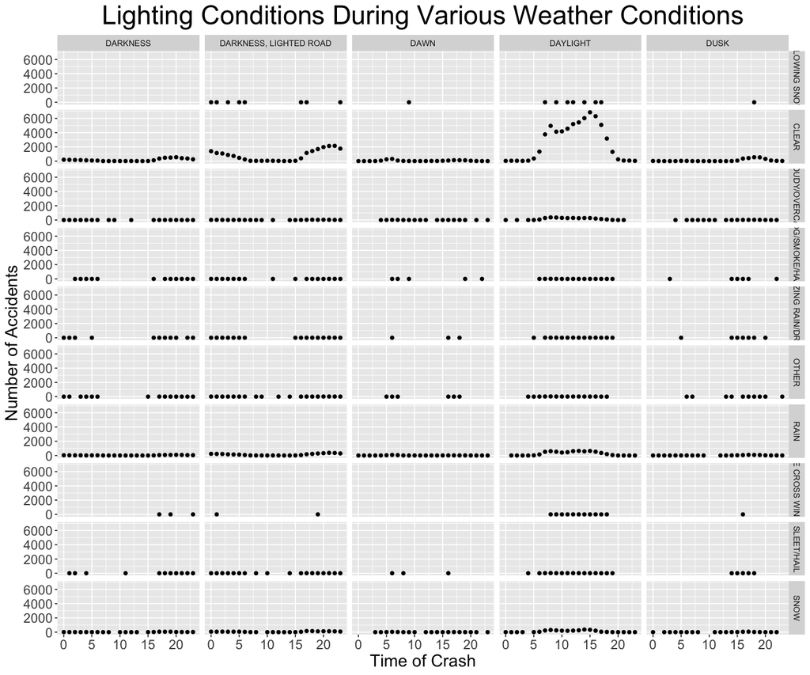

```r
ggplot(data = crashes_lighting) +
    geom_point(mapping = aes(x = CRASH_HOUR, y = NUM_ACCIDENTS)) +
    facet_grid(WEATHER_CONDITION ~ LIGHTING_CONDITION ) +
    xlab("Time of Crash") + ylab("Number of Accidents") +
    ggtitle("Lighting Conditions During Various Weather Conditions") +
    theme(plot.title = element_text(hjust = 0.5, size = 28),
        axis.text = element_text(size=14),
        axis.title.x = element_text(size=18),
        axis.title.y = element_text(size=18))
```

Since we have analyzed that the most accidents occur when the weather is clear, analyzing the different lighting (and essentially time of crash) shows us that the majority of crashes happen in daylight. This again is interesting because the assumption usually is that darkness makes it harder to see and presents more danger on the road.

## Conclusion for question 1

Analyzing the weather condition, road defects, and lighting condition has shown that different weather condition and lighing have little affect on the number of accidents. However, with clear weather and in daylight, there are possible road defects that may cause more accidents. To answer the question, possible road defects from different weather conditions on a previous day may cause accidents on a clear, bright day if not careful.

# Question 2: Which vehicle brands and models were most involved in accidents?

Traffic crashes can occur much more often for certain car brands than others, and some car models can be involved in crashes more frequently regardless as to how often their car brand recieves accident reports. The Vehicles dataset, which consists of information about vehicles involved in a traffic crash, should be associated with the Crashes dataset to identify both the car models and brands with the most accidents and how these car models and brands compare with one another. Understanding more about the frequency of car brands/models on the accidents reported in the Crashes dataset can be important for car manufacturers and companies to be aware of reducing the number of traffic crashes for each of their cars.

According to the description of the Vehicles dataset from Chicago Data Portal, Vehicle information is linked back to the Crash data using the “CRASH_RECORD_ID” field. We will join the two datasets by CRASH_RECORD_ID to only return rows with matching keys for both datasets. The car makes and models were originally ordered by date, so we first ordered the row values from highest to lowest based on the accident count values for the car makes. The NA values were removed, and the first ten rows were selected.

```r
tidydf <- inner_join(traffic, vehicle, by = "CRASH_RECORD_ID") %>% print()

vehicle_crashes <- tidydf %>% select(MAKE, MODEL) %>% group_by(MAKE) %>% summarize(accident_count = n()) %>%
arrange(desc(accident_count)) %>% slice(-c(4,10)) %>% slice(c(1:10)) %>% print
```

```
# A tibble: 240,141 x 111
      X1 CRASH_RECORD_ID RD_NO.x CRASH_DATE.x POSTED_SPEED_LI… TRAFFIC_CONTROL…
   <dbl> <chr>           <chr>   <chr>                   <dbl> <chr>
 1     2 1560fb8a1e32b5… JC3259… 06/27/2019 …               45 NO CONTROLS
 2     2 1560fb8a1e32b5… JC3259… 06/27/2019 …               45 NO CONTROLS
 3     5 00e47f189660cd… JC1947… 03/21/2019 …               30 TRAFFIC SIGNAL
 4     5 00e47f189660cd… JC1947… 03/21/2019 …               30 TRAFFIC SIGNAL
 5     8 0211e1f766f394… JC3014… 06/11/2019 …               30 TRAFFIC SIGNAL
 6     8 0211e1f766f394… JC3014… 06/11/2019 …               30 TRAFFIC SIGNAL
 7    15 046c0f96fdf5f7… JC1282… 01/24/2019 …               30 NO CONTROLS
 8    15 046c0f96fdf5f7… JC1282… 01/24/2019 …               30 NO CONTROLS
 9    17 0564e565ebda93… JC5419… 12/10/2019 …               20 TRAFFIC SIGNAL
10    17 0564e565ebda93… JC5419… 12/10/2019 …               20 TRAFFIC SIGNAL
# … with 240,131 more rows, and 105 more variables: DEVICE_CONDITION <chr>,
#   WEATHER_CONDITION <chr>, LIGHTING_CONDITION <chr>, FIRST_CRASH_TYPE <chr>,
#   TRAFFICWAY_TYPE <chr>, LANE_CNT <dbl>, ALIGNMENT <chr>,
#   ROADWAY_SURFACE_COND <chr>, ROAD_DEFECT <chr>, REPORT_TYPE <chr>,
#   CRASH_TYPE <chr>, DAMAGE <chr>, DATE_POLICE_NOTIFIED <chr>,
#   PRIM_CONTRIBUTORY_CAUSE <chr>, SEC_CONTRIBUTORY_CAUSE <chr>,
#   STREET_NO <dbl>, STREET_DIRECTION <chr>, STREET_NAME <chr>,
#   BEAT_OF_OCCURRENCE <dbl>, NUM_UNITS <dbl>, MOST_SEVERE_INJURY <chr>,
#   INJURIES_TOTAL <dbl>, INJURIES_FATAL <dbl>, INJURIES_INCAPACITATING <dbl>,
#   INJURIES_NON_INCAPACITATING <dbl>, INJURIES_REPORTED_NOT_EVIDENT <dbl>,
#   INJURIES_NO_INDICATION <dbl>, INJURIES_UNKNOWN <dbl>, CRASH_HOUR <dbl>,
#   CRASH_DAY_OF_WEEK <dbl>, CRASH_MONTH <dbl>, LATITUDE <dbl>,
#   LONGITUDE <dbl>, LOCATION <chr>, CRASH_UNIT_ID <dbl>, RD_NO.y <chr>,
#   CRASH_DATE.y <chr>, UNIT_NO <dbl>, UNIT_TYPE <chr>, NUM_PASSENGERS <dbl>,
#   VEHICLE_ID <dbl>, CMRC_VEH_I <chr>, MAKE <chr>, MODEL <chr>,
#   LIC_PLATE_STATE <chr>, VEHICLE_YEAR <dbl>, VEHICLE_DEFECT <chr>,
#   VEHICLE_TYPE <chr>, VEHICLE_USE <chr>, TRAVEL_DIRECTION <chr>,
#   MANEUVER <chr>, TOWED_I <chr>, FIRE_I <lgl>, OCCUPANT_CNT <dbl>,
#   EXCEED_SPEED_LIMIT_I <chr>, TOWED_BY <chr>, TOWED_TO <chr>,
#   AREA_00_I <chr>, AREA_01_I <chr>, AREA_02_I <chr>, AREA_03_I <chr>,
#   AREA_04_I <chr>, AREA_05_I <chr>, AREA_06_I <chr>, AREA_07_I <chr>,
#   AREA_08_I <chr>, AREA_09_I <lgl>, AREA_10_I <chr>, AREA_11_I <chr>,
#   AREA_12_I <chr>, AREA_99_I <chr>, FIRST_CONTACT_POINT <chr>, CMV_ID <dbl>,
#   USDOT_NO <lgl>, CCMC_NO <dbl>, ILCC_NO <lgl>, COMMERCIAL_SRC <chr>,
#   GVWR <dbl>, CARRIER_NAME <chr>, CARRIER_STATE <chr>, CARRIER_CITY <chr>,
#   HAZMAT_PLACARDS_I <lgl>, HAZMAT_NAME <lgl>, UN_NO <lgl>,
#   HAZMAT_PRESENT_I <chr>, HAZMAT_REPORT_I <chr>, HAZMAT_REPORT_NO <lgl>,
#   MCS_REPORT_I <chr>, MCS_REPORT_NO <lgl>, HAZMAT_VIO_CAUSE_CRASH_I <chr>,
#   MCS_VIO_CAUSE_CRASH_I <chr>, IDOT_PERMIT_NO <dbl>, WIDE_LOAD_I <lgl>,
#   TRAILER1_WIDTH <chr>, TRAILER2_WIDTH <lgl>, TRAILER1_LENGTH <lgl>,
#   TRAILER2_LENGTH <lgl>, TOTAL_VEHICLE_LENGTH <lgl>, AXLE_CNT <dbl>,
#   VEHICLE_CONFIG <chr>, …
# A tibble: 10 x 2
   MAKE                       accident_count
   <chr>                               <int>
 1 CHEVROLET                           26794
 2 TOYOTA MOTOR COMPANY, LTD.          26371
 3 FORD                                23198
 4 NISSAN                              19869
 5 HONDA                               17252
 6 DODGE                               10501
 7 HYUNDAI                             10303
 8 JEEP                                 9310
 9 KIA MOTORS CORP                      5730
10 VOLKSWAGEN                           4639
```

We have saved the vehicle_crashes tibble to create a horizontal bar chart to represent values of the highest accident counts for each car make.

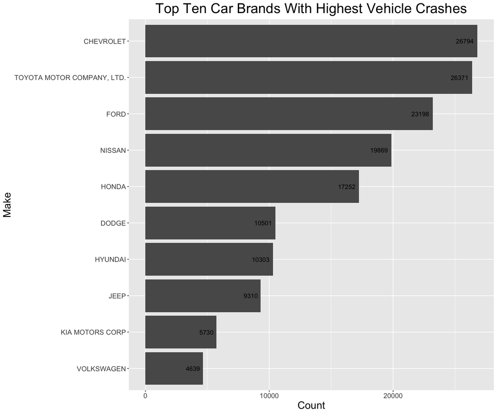

```r
vehicle_crashes %>% ggplot(aes(x = reorder(MAKE, accident_count), y = accident_count)) + geom_col() +
geom_text(aes(label = accident_count), hjust = 1.2) + xlab("Make") + ylab("Count") + coord_flip() +
ggtitle("Top Ten Car Brands With Highest Vehicle Crashes") +
    theme(plot.title = element_text(hjust = 0.5, size = 24),
        axis.text = element_text(size=12),
        axis.title.x = element_text(size=18),
        axis.title.y = element_text(size=18))
```

## Observations about the graph

In Chicago of 2019, Chevrolet appears to be the car brand that has had the most car accidents, and Volkswagen appears to have had the least amount of accidents. The uncertainty with these findings are that these car brands do not have similar sizes in both the amount and type of model cars they produce annually.

To get more details on the car brands, we created a horizontal bar chart of the car models involved in the most accidents. We concatenated the MAKE character vectors to the MODEL character vectors in order to be clear on which car model belonged to which car brand. The top ten rows from the highest to lowest number of accident counts for car models were saved. According to the tibble, the second and seventh row had slightly irrelevent string characters. Therefore to be clear in the y-axis labelling, the Nissan company was set to just its car brand and model name in the bar chart.

```
# A tibble: 10 x 2
   MAKE_MODEL                                    accident_count
   <chr>                                                  <int>
 1 TOYOTA MOTOR COMPANY, LTD. CAMRY                        7800
 2 NISSAN NISSAN ALTIMA                                    5172
 3 TOYOTA MOTOR COMPANY, LTD. COROLLA                      4701
 4 HONDA CIVIC                                             4523
 5 CHEVROLET MALIBU (CHEVELLE)                             4259
 6 HONDA ACCORD                                            4013
 7 NISSAN SENTRA (DATSUN AND NISSAN HAVE MERGED)           3538
 8 CHEVROLET IMPALA                                        3204
 9 HYUNDAI ELANTRA                                         3009
10 HONDA CRV                                               2919
```

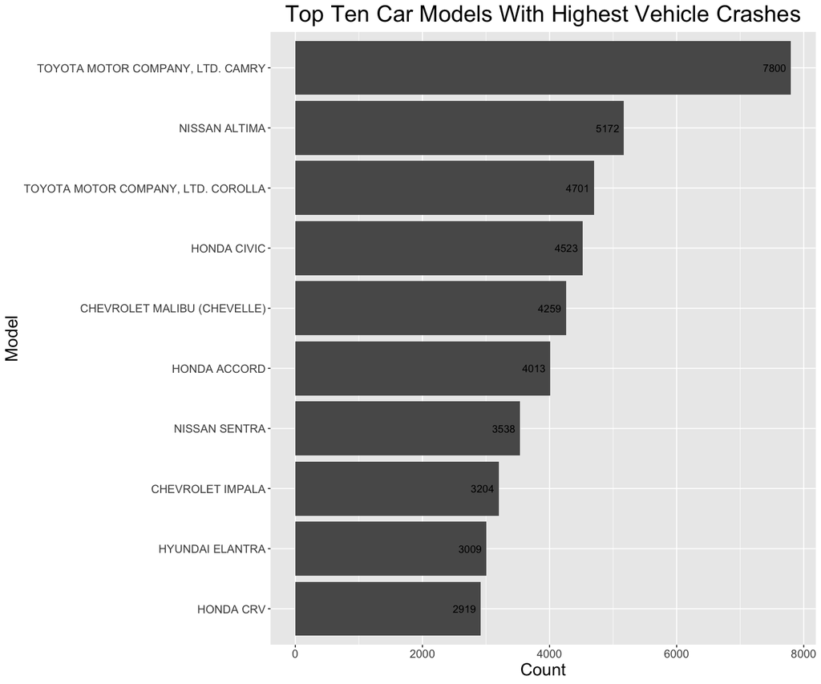

```r
vehicle_crashes2 <- tidydf %>% select(MAKE, MODEL) %>% filter(MAKE != "UNKNOWN", MODEL != "UNKNOWN") %>%
mutate(MAKE_MODEL = paste(MAKE, MODEL, sep = " ")) %>% group_by(MAKE_MODEL) %>%
summarize(accident_count = n()) %>% arrange(desc(accident_count)) %>% slice(1:10) %>% print()

vehicle_crashes2[2,1] <- "NISSAN ALTIMA"
vehicle_crashes2[7,1] <- "NISSAN SENTRA"

vehicle_crashes2 %>% ggplot(aes(x = reorder(MAKE_MODEL, accident_count), y = accident_count)) + geom_col() +
geom_text(aes(label = accident_count), hjust = 1.2) + xlab("Model") + ylab("Count") + coord_flip() +
ggtitle("Top Ten Car Models With Highest Vehicle Crashes") +
    theme(plot.title = element_text(hjust = 0.5, size = 24),
        axis.text = element_text(size=12),
        axis.title.x = element_text(size=18),
        axis.title.y = element_text(size=18))
```

## Observations about the graph

Honda appears to be the car brand with its most models in the top ten number of car accidents for 2019 in Chicago. Although the Chevrolet company had the most amount of car accidents, two of their car models were not in the top four for number of car accidents. Another interesting observation is that no Ford car models were in the top ten models for number of accidents even if this company was third when comparing companies as a whole.

We created a tibble of the Toyota Camry's most signifcant factors which caused its crashes in the year.

```r
tidydf %>% select(MAKE, MODEL, PRIM_CONTRIBUTORY_CAUSE) %>%
filter(MAKE == "TOYOTA MOTOR COMPANY, LTD." & MODEL == "CAMRY") %>%
group_by(PRIM_CONTRIBUTORY_CAUSE) %>% summarize(n = n()) %>% arrange(desc(n))
```

A tibble: 38 × 2

| PRIM_CONTRIBUTORY_CAUSE <chr> | n <int> |
| --- | --- |
| UNABLE TO DETERMINE | 2659 |
| FAILING TO YIELD RIGHT-OF-WAY | 1004 |
| FOLLOWING TOO CLOSELY | 901 |
| IMPROPER OVERTAKING/PASSING | 424 |
| FAILING TO REDUCE SPEED TO AVOID CRASH | 396 |
| IMPROPER LANE USAGE | 361 |
| NOT APPLICABLE | 338 |
| IMPROPER BACKING | 309 |
| IMPROPER TURNING/NO SIGNAL | 293 |
| DRIVING SKILLS/KNOWLEDGE/EXPERIENCE | 256 |
| DISREGARDING TRAFFIC SIGNALS | 143 |
| WEATHER | 131 |
| OPERATING VEHICLE IN ERRATIC, RECKLESS, CARELESS, NEGLIGENT OR AGGRESSIVE MANNER | 84 |
| DISREGARDING STOP SIGN | 71 |
| DISTRACTION - FROM INSIDE VEHICLE | 53 |
| VISION OBSCURED (SIGNS, TREE LIMBS, BUILDINGS, ETC.) | 52 |
| PHYSICAL CONDITION OF DRIVER | 43 |
| DISTRACTION - FROM OUTSIDE VEHICLE | 38 |
| UNDER THE INFLUENCE OF ALCOHOL/DRUGS (USE WHEN ARREST IS EFFECTED) | 38 |
| EQUIPMENT - VEHICLE CONDITION | 35 |
| DRIVING ON WRONG SIDE/WRONG WAY | 27 |
| EVASIVE ACTION DUE TO ANIMAL, OBJECT, NONMOTORIST | 18 |
| ROAD ENGINEERING/SURFACE/MARKING DEFECTS | 18 |
| CELL PHONE USE OTHER THAN TEXTING | 17 |
| EXCEEDING SAFE SPEED FOR CONDITIONS | 16 |
| ROAD CONSTRUCTION/MAINTENANCE | 15 |
| DISREGARDING OTHER TRAFFIC SIGNS | 13 |
| EXCEEDING AUTHORIZED SPEED LIMIT | 13 |
| DISREGARDING ROAD MARKINGS | 8 |
| HAD BEEN DRINKING (USE WHEN ARREST IS NOT MADE) | 7 |
| ANIMAL | 6 |
| DISTRACTION - OTHER ELECTRONIC DEVICE (NAVIGATION DEVICE, DVD PLAYER, ETC.) | 3 |
| TURNING RIGHT ON RED | 3 |
| DISREGARDING YIELD SIGN | 2 |
| TEXTING | 2 |
| MOTORCYCLE ADVANCING LEGALLY ON RED LIGHT | 1 |
| OBSTRUCTED CROSSWALKS | 1 |
| RELATED TO BUS STOP | 1 |

## Conclusion for question 2

When looking through a joined dataset of the Vehicles and Crashes data, the perfomance of car models does not directly connect to the performance of the car company and vice versa. The factors which were the most significant in causing crashes for the Toyota Camry was due to human error. To get an explanation why Toyota Camry had more than over 3000 accidents than the Chevy Malibu is mostly due to human error.

However, some leading causes such as following cars too closely could be partly due to the functioning of the car. There are inconsistenies of how car companies such as Chevrolet can produce more car models with less cases of accidents.

# Question 3: How many and what type of crashes occurred each month?

Different months experience varying volumes of crashes, as well as varying volumes of the type of responses. Understanding the number of crashes per month, and the types of crashes per month, can help police departments assign more officers on road safety and appropriate emergency response teams based on most common type of crash that occurs during those months.

We saved a tibble to use to create a line graph that has each month represented across the x-axis and the accident count across the y-axis. To do this, we created a variable called Accidents_by_Month, which selects CRASH_RECORD_ID and CRASH_MONTH from the traffic dataset, arranges CRASH_MONTH in ascending order, then groups by CRASH_MONTH, and then counts the number of accidents per month.

```r
Accidents_by_Month= traffic %>%
select(CRASH_RECORD_ID, CRASH_MONTH)%>%
group_by(CRASH_MONTH) %>%
arrange(CRASH_MONTH)%>% summarize(Accident_Count = n()) %>% print()
```

```
# A tibble: 12 x 2
   CRASH_MONTH Accident_Count
         <dbl>          <int>
 1           1           9116
 2           2           8624
 3           3           9748
 4           4           9445
 5           5          10707
 6           6          10706
 7           7          10658
 8           8           9940
 9           9           9813
10          10           9937
11          11           9639
12          12           9415
```

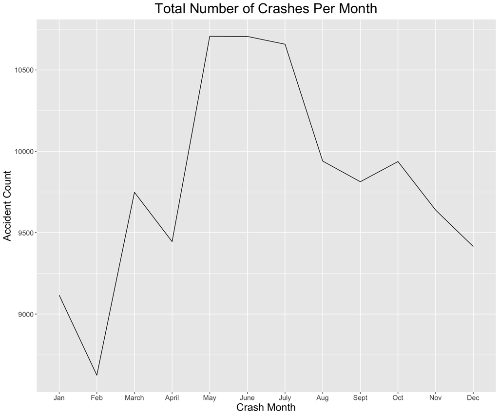

```r
ggplot(data= Accidents_by_Month)+
geom_line(mapping = aes(x = CRASH_MONTH, y = Accident_Count),
         stat = "identity") + xlab("Crash Month") + ylab("Accident Count") +
scale_x_discrete(limits=c("Jan","Feb","March", "April","May","June","July","Aug", "Sept", "Oct", "Nov", "Dec"))+
ggtitle("Total Number of Crashes Per Month") +
    theme(plot.title = element_text(hjust = 0.5, size = 24),
        axis.text = element_text(size=12),
        axis.title.x = element_text(size=18),
        axis.title.y = element_text(size=18))
```

## Observations about the graph

Something that could be interesting to investigate is if the higher number of crashes in May have to do with a lot of roadwork during those months, as well as if May experienced higher levels of rain or other weather disruptions than other months. Similarly, perhaps February experienced better weather conditions, as well as less roadwork.

```r
total_num_accidents<-traffic%>%nrow()%>%print
percent_accident_count<-Accidents_by_Month %>% mutate(percent_of_accidents = Accident_Count/total_num_accidents) %>%
                        print
performance_accident_count<-lm(percent_of_accidents~CRASH_MONTH,data=percent_accident_count)
summary(performance_accident_count)
```

```
[1] 117748
# A tibble: 12 x 3
   CRASH_MONTH Accident_Count percent_of_accidents
         <dbl>          <int>                <dbl>
 1           1           9116               0.0774
 2           2           8624               0.0732
 3           3           9748               0.0828
 4           4           9445               0.0802
 5           5          10707               0.0909
 6           6          10706               0.0909
 7           7          10658               0.0905
 8           8           9940               0.0844
 9           9           9813               0.0833
10          10           9937               0.0844
11          11           9639               0.0819
12          12           9415               0.0800
```

```
Call:
lm(formula = percent_of_accidents ~ CRASH_MONTH, data = percent_accident_count)

Residuals:
       Min         1Q     Median         3Q        Max
-0.0083232 -0.0033687 -0.0006471  0.0023685  0.0081878

Coefficients:
             Estimate Std. Error t value Pr(>|t|)
(Intercept) 0.0807782  0.0034130  23.668 4.11e-10 ***
CRASH_MONTH 0.0003931  0.0004637   0.848    0.416
---
Signif. codes:  0 ‘***’ 0.001 ‘**’ 0.01 ‘*’ 0.05 ‘.’ 0.1 ‘ ’ 1

Residual standard error: 0.005545 on 10 degrees of freedom
Multiple R-squared:  0.06704,	Adjusted R-squared:  -0.02626
F-statistic: 0.7186 on 1 and 10 DF,  p-value: 0.4164
```

## Observations about the linear regression

It would also be interesting to investigate the number of type of accidents that occurred during these months.

To do this, we can identify the types of crash types that exist in this dataset. We have selected CRASH_TYPE from the traffic dataset, and then used unique() to identify the unique crash types.

```r
traffic %>% select(CRASH_TYPE)%>% unique()
```

A tibble: 2 × 1

| CRASH_TYPE <chr> |
| --- |
| NO INJURY / DRIVE AWAY |
| INJURY AND / OR TOW DUE TO CRASH |

When we do this, we find that there are two crash types in this dataset, which are "NO INJURY / DRIVE AWAY" and "INJURY AND / OR TOW DUE TO CRASH". Next, we can count the number of each type of crash per month.

To do this, we selected the CRASH_TYPE and CRASH_MONTH columns from the traffic dataset, grouped by CRASH_MONTH and CRASH_TYPE, and counted the number of times that type of accident occurred per month, which is listed in another column called n. Then, we filtered the CRASH_TYPE to find crashes and their count that are classified as: "INJURY AND / OR TOW DUE TO CRASH". We repeated this process for crashes that are classified as: "NO INJURY / DRIVE AWAY".

```r
traffic %>% select(CRASH_TYPE, CRASH_MONTH)%>%
arrange(CRASH_MONTH) %>% group_by(CRASH_MONTH, CRASH_TYPE) %>% summarize(n=n())%>%
filter(CRASH_TYPE=="INJURY AND / OR TOW DUE TO CRASH")
```

A grouped_df: 12 × 3

| CRASH_MONTH <dbl> | CRASH_TYPE <chr> | n <int> |
| --- | --- | --- |
| 1 | INJURY AND / OR TOW DUE TO CRASH | 2305 |
| 2 | INJURY AND / OR TOW DUE TO CRASH | 2093 |
| 3 | INJURY AND / OR TOW DUE TO CRASH | 2548 |
| 4 | INJURY AND / OR TOW DUE TO CRASH | 2490 |
| 5 | INJURY AND / OR TOW DUE TO CRASH | 2717 |
| 6 | INJURY AND / OR TOW DUE TO CRASH | 2741 |
| 7 | INJURY AND / OR TOW DUE TO CRASH | 2792 |
| 8 | INJURY AND / OR TOW DUE TO CRASH | 2686 |
| 9 | INJURY AND / OR TOW DUE TO CRASH | 2726 |
| 10 | INJURY AND / OR TOW DUE TO CRASH | 2850 |
| 11 | INJURY AND / OR TOW DUE TO CRASH | 2653 |
| 12 | INJURY AND / OR TOW DUE TO CRASH | 2622 |

```r
traffic %>% select(CRASH_TYPE, CRASH_MONTH)%>%
arrange(CRASH_MONTH) %>% group_by(CRASH_MONTH, CRASH_TYPE) %>% summarize(n=n())%>%
filter(CRASH_TYPE=="NO INJURY / DRIVE AWAY")
```

A grouped_df: 12 × 3

| CRASH_MONTH <dbl> | CRASH_TYPE <chr> | n <int> |
| --- | --- | --- |
| 1 | NO INJURY / DRIVE AWAY | 6811 |
| 2 | NO INJURY / DRIVE AWAY | 6531 |
| 3 | NO INJURY / DRIVE AWAY | 7200 |
| 4 | NO INJURY / DRIVE AWAY | 6955 |
| 5 | NO INJURY / DRIVE AWAY | 7990 |
| 6 | NO INJURY / DRIVE AWAY | 7965 |
| 7 | NO INJURY / DRIVE AWAY | 7866 |
| 8 | NO INJURY / DRIVE AWAY | 7254 |
| 9 | NO INJURY / DRIVE AWAY | 7087 |
| 10 | NO INJURY / DRIVE AWAY | 7087 |
| 11 | NO INJURY / DRIVE AWAY | 6986 |
| 12 | NO INJURY / DRIVE AWAY | 6793 |

We saved the tables created above as injury_crash_type and noninjury_crash_type. We then created a a plot with 2 line graphs, with each line representing each crash type. These graphs show the the number of crashes for each crash type each month, which can be compared to the graph we created above to learn more about the crashes in this dataset. Based on the graph, there are more crashes each month that are classified as: "NO INJURY/DRIVE AWAY".

It would be interesting to look at the weather and road conditions during these months too to see why this is.

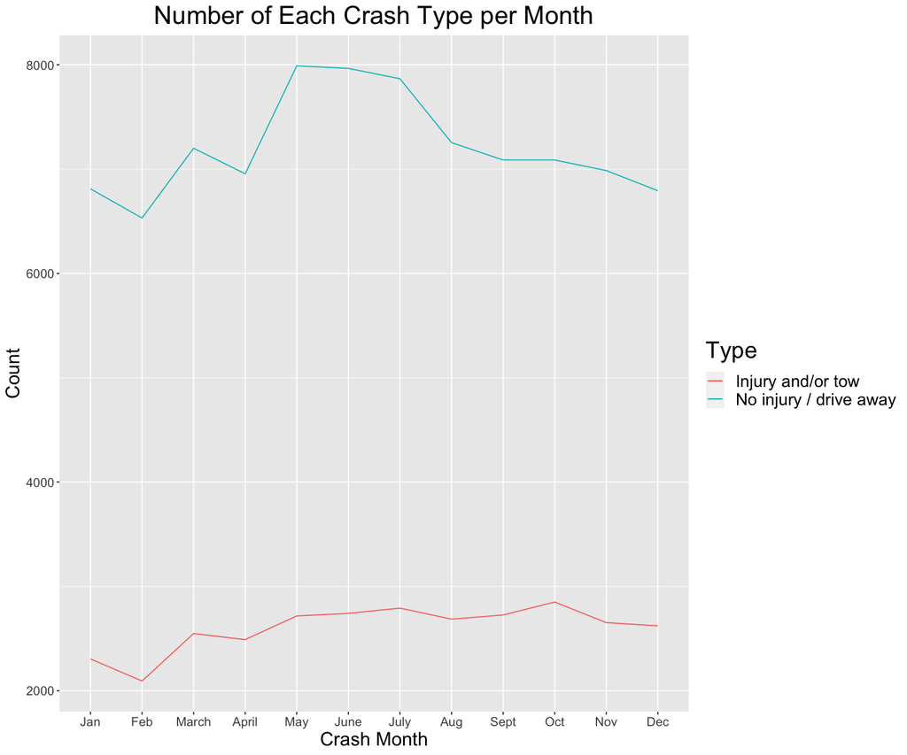

```r
injury_crash_type= traffic %>% select(CRASH_TYPE, CRASH_MONTH)%>%
arrange(CRASH_MONTH) %>% group_by(CRASH_MONTH, CRASH_TYPE) %>% summarize(n=n())%>%
filter(CRASH_TYPE=="INJURY AND / OR TOW DUE TO CRASH")

noninjury_crash_type= traffic %>% select(CRASH_TYPE, CRASH_MONTH)%>%
arrange(CRASH_MONTH) %>% group_by(CRASH_MONTH, CRASH_TYPE) %>% summarize(n=n())%>%
filter(CRASH_TYPE=="NO INJURY / DRIVE AWAY")

ggplot() +
  geom_line(data = injury_crash_type, mapping= aes(x = CRASH_MONTH, y = n, color = "blue")) +
  geom_line(data = noninjury_crash_type, mapping= aes(x = CRASH_MONTH, y = n, color = "red")) +
  xlab('Crash Month')+ylab('Count')+
  scale_x_discrete(limits=c("Jan","Feb","March", "April","May","June","July","Aug", "Sept", "Oct", "Nov", "Dec")) +
  scale_color_discrete(name = "Type", labels = c("Injury and/or tow", "No injury / drive away")) +
ggtitle("Number of Each Crash Type per Month") +
    theme(plot.title = element_text(hjust = 0.5, size = 24),
        axis.text = element_text(size=12),
        legend.title = element_text(size = 22),
        legend.text = element_text(size = 16),
        axis.title.x = element_text(size=18),
        axis.title.y = element_text(size=18))
```

## Conclusion for question 3

As mentioned, an important caveat applies: we are analyzing only one year of traffic crash data in Chicago. The sample size is limited, so the conclusions are limited by it.

# Question 4: What can we learn about accidents and fatalities?

Many accidents do not result in injuries or deaths. However, some of the most serious crashes lead to one or more fatalities. These events should be of particular interest to city leadership, as they represent a loss of life. Understanding more about these fatal events is the first step to working to prevent them.

## Plotting fatal accidents on a map of Chicago

Let's start by taking a look at where fatal crashes occur within the city of Chicago. For our map visualization we will use `ggmap()`, as provided by:

> D. Kahle and H. Wickham. ggmap: Spatial Visualization with ggplot2. The R Journal, 5(1), 144-161. URL http://journal.r-project.org/archive/2013-1/kahle-wickham.pdf

```r
downtown_lat <- 41.8757
downtown_lon <- -87.6243

aa_clean <- traffic %>%
    filter(!is.na(LATITUDE) | !is.na(LONGITUDE)) %>%
    filter(LATITUDE >= downtown_lat - 2 & LATITUDE <= downtown_lat + 2) %>%
    filter(LONGITUDE >= downtown_lon - 2 & LONGITUDE <= downtown_lon + 2)

fa_clean <- aa_clean %>%
    filter(INJURIES_FATAL > 0)
```

Now we will produce a map of Chicago and plot where fatal accidents have occurred.

[figure not shown]

```r
chicago_map <- suppressMessages(
    ggmap(get_stamenmap(rbind(as.numeric(paste(geocode_OSM("Chicago")$bbox))), zoom = 11))
    )

chicago_map + geom_point(aes(x = LONGITUDE, y = LATITUDE), data = fa_clean) +
    xlab("Longitude") +
    ylab("Latitude") +
    ggtitle("Chicago fatal accident locations") +
    theme(plot.title = element_text(hjust = 0.5, size = 28))
```

## Observations about the graph

In our map of Chicago above, it appears that fatal accidents are somewhat evenly spread throughout the city. No particular area seems to be much deadlier than the others. We analyzed a number of variables (including weather conditions, lighting conditions, traffic control devices, and others) in an attempt to discover factors that may contribute to fatal accidents. With no clear answers, we decided to break the city into geographical sections for different ways to look at the data.

## Analysis by city quadrant

Here we perform data modifications in order to separate the city into four geographic quadrants:

- NW
- NE
- SW
- SE

And examine what we can learn about death rate in the context of city quadrants.

```r
aa_quad <- aa_clean %>%
    mutate(nw_quadrant = ifelse(LATITUDE > downtown_lat & LONGITUDE < downtown_lon, "NW", NA)) %>%
    mutate(ne_quadrant = ifelse(LATITUDE > downtown_lat & LONGITUDE > downtown_lon, "NE", NA)) %>%
    mutate(sw_quadrant = ifelse(LATITUDE < downtown_lat & LONGITUDE < downtown_lon, "SW", NA)) %>%
    mutate(se_quadrant = ifelse(LATITUDE < downtown_lat & LONGITUDE > downtown_lon, "SE", NA)) %>%
    gather(nw_quadrant, ne_quadrant, sw_quadrant, se_quadrant, key = "foo", value = "quadrant", na.rm = TRUE) %>%
    select(-foo)

fa_quad <- aa_quad %>%
    filter(INJURIES_FATAL > 0)
```

Next, we re-analyzed several different variables by quadrant categories. None were found to provide significant insight, so we attempted to look at a "common sense" variable cause of fatal accidents: speed limit.

Because there are many different posted speed limits, we categorize them into just two buckets for simplified analysis:

- High-speed - 35mph or above
- Low-speed - less than 35mph

```r
high_speed_mph = 35

aa_speed <- aa_quad %>%
    mutate(posted_speed = ifelse(POSTED_SPEED_LIMIT >= high_speed_mph, "High-speed", "Low-speed")) %>%
    group_by(quadrant, posted_speed) %>%
    summarize(count = n())

fa_speed <- fa_quad %>%
    mutate(posted_speed = ifelse(POSTED_SPEED_LIMIT >= high_speed_mph, "High-speed", "Low-speed")) %>%
    group_by(quadrant, posted_speed) %>%
    summarize(deaths = sum(INJURIES_FATAL)) %>%
    inner_join(aa_speed, by = c("quadrant", "posted_speed")) %>%
    mutate(death_rate = (deaths / count) * 100) %>%
    arrange(desc(death_rate))

print(fa_speed)
```

```
# A tibble: 8 x 5
# Groups:   quadrant [4]
  quadrant posted_speed deaths count death_rate
  <chr>    <chr>         <dbl> <int>      <dbl>
1 SE       High-speed        6  2338     0.257
2 NW       High-speed        7  3760     0.186
3 NE       High-speed        1   631     0.158
4 SE       Low-speed        21 13943     0.151
5 NE       Low-speed         3  2060     0.146
6 SW       Low-speed        32 36431     0.0878
7 NW       Low-speed        34 54295     0.0626
8 SW       High-speed        2  3362     0.0595
```

## Graphing posted speed limit by quadrant

With our newly-tidied data, let's take a look at posted speed limit and its relationship with fatal accidents, by city quadrant.

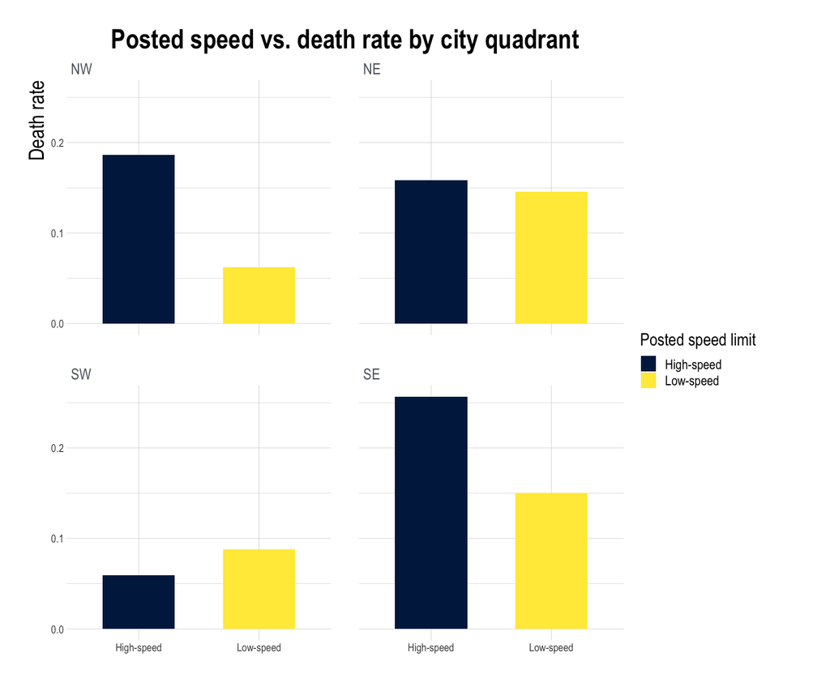

```r
fa_speed <- fa_speed %>%
    mutate(quadrant = factor(quadrant, levels = c("NW", "NE", "SW", "SE")))

oldw <- getOption("warn")
options(warn = -1)

ggplot(data = fa_speed, aes(fill = posted_speed, x = posted_speed, y = death_rate)) +
    geom_bar(position="dodge", stat="identity", width=.6) +
    scale_fill_viridis(discrete = T, option = "E") +
    ggtitle("Posted speed vs. death rate by city quadrant") +
    facet_wrap(~quadrant) +
    theme_ipsum() +
    theme(plot.title = element_text(hjust = 0.5, size = 28),
          axis.text = element_text(size=18),
          axis.title.y = element_text(size=22),
        legend.title = element_text(size = 18),
        legend.text = element_text(size = 14)) +
    theme(strip.text.x = element_text(size = 16, colour = "#5e6570")) +
    xlab("") +
    ylab("Death rate") +
    labs(fill = "Posted speed limit")

options(warn = oldw)
```

## Observations about the graph

According to the quadrant graph above, our "common sense" assumption about high speed and fatalities may not be correct for this dataset. Indeed, in one quadrant low-speed crashes have a higher rate of fatalities! (It is also possible our sample size is too small to show the relationship meaningfully.) After further analysis with other variables -- not shown here for the sake of brevity -- viewing the data by quadrant does not provide significant insight.

## Analysis by East and West sides of city

On a hunch, given Chicago's proximity to Lake Michigan, and the effect that may have on road conditions, we decide to try another round of data modification. This time we split the city into halves:

- East
- West

And then examine variables through this new lens.

```r
aa_split <- aa_clean %>%
    mutate(west = ifelse(LONGITUDE < downtown_lon, "West", NA)) %>%
    mutate(east = ifelse(LONGITUDE > downtown_lon, "East", NA)) %>%
    gather(west, east, key = "foo", value = "city_side", na.rm = TRUE) %>%
    select(-foo) %>%
    mutate(city_side = factor(city_side, levels = c("West", "East")))

fa_split <- aa_split %>%
    filter(INJURIES_FATAL > 0)
```

## Graphing surface condition by city side

After examining a number of variables in the context of city side, our earlier hunch finally leads us to some telling new insight about the lake effect. This seems to be confirmed in the following graph.

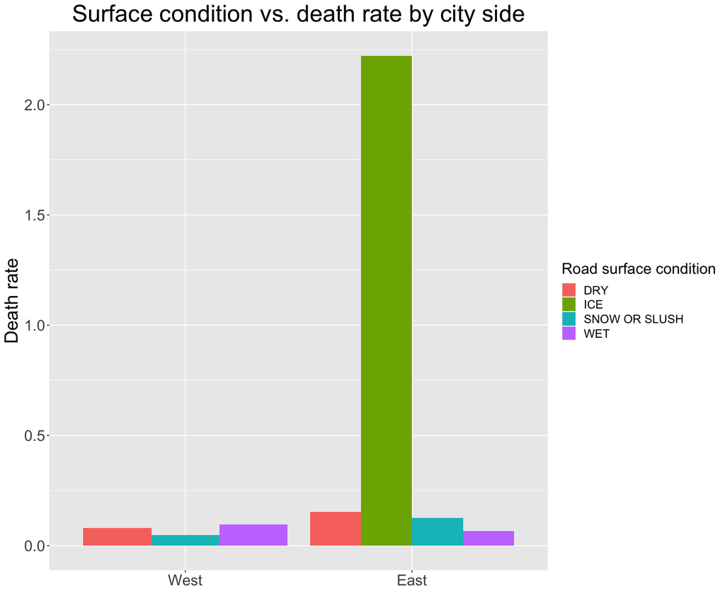

```r
aa_road <- aa_split %>%
    filter(ROADWAY_SURFACE_COND != "UNKNOWN") %>%
    group_by(city_side, ROADWAY_SURFACE_COND) %>%
    summarize(count = n())

fa_road <- fa_split %>%
    filter(ROADWAY_SURFACE_COND != "UNKNOWN") %>%
    group_by(city_side, ROADWAY_SURFACE_COND) %>%
    summarize(deaths = sum(INJURIES_FATAL)) %>%
    inner_join(aa_road, by = c("city_side", "ROADWAY_SURFACE_COND")) %>%
    mutate(death_rate = (deaths / count) * 100) %>%
    arrange(desc(city_side), desc(death_rate))

oldw <- getOption("warn")
options(warn = -1)

ggplot(data = fa_road) +
    geom_bar(mapping = aes(x = city_side, y = death_rate, fill = ROADWAY_SURFACE_COND),
         stat = "identity", position = "dodge") +
    xlab("") +
    ylab("Death rate") +
    theme(plot.title = element_text(hjust = 0.5, size = 28),
        legend.title = element_text(size = 18),
        legend.text = element_text(size = 14),
        axis.text = element_text(size=18),
        axis.title.y = element_text(size=22)) +
    ggtitle("Surface condition vs. death rate by city side") +
    labs(fill = "Road surface condition")
```

## Observations about the graph

As hypothesized, the graph of surface conditions by city side -- and its relationship to death rate -- provides an interesting insight. It appears that the east side of the city (which is the side next to Lake Michigan) has a significant death rate associated with icy road conditions. The usual caveat applies: our data sample is small, so our conclusion here may be incorrect given a larger dataset.

## Cause of accident and its relation to death

As a final look at fatal accident variables and insights, we analyze the recorded causes of accidents to see whether they impact the death rate. Are some accident causes more deadly than others? Let's find out below, using one more round of data modification and a graph.

```r
fa_cause <- aa_clean %>%
    mutate(pc = PRIM_CONTRIBUTORY_CAUSE) %>%
    mutate(c1 = ifelse(pc == "NOT APPLICABLE" | pc == "UNABLE TO DETERMINE", "Unknown", NA)) %>%
    mutate(c2 = ifelse(grepl("DISTRACTION", pc), "Distracted", NA)) %>%
    mutate(c3 = ifelse(grepl("SPEED", pc), "Speeding", NA)) %>%
    mutate(c4 = ifelse(grepl("DISREGARD|RECKLESS|IMPROPER|FAIL.*YIELD|FOLLOW.*CLOSE", pc) , "Reckless", NA)) %>%
    mutate(c5 = ifelse(grepl("ALCOHOL.DRUGS", pc) , "Intoxicated", NA)) %>%
    mutate(c6 = ifelse(grepl("PHYSICAL CONDITION", pc) , "Driver health", NA)) %>%
    mutate(c7 = ifelse(grepl("SKILLS.KNOW", pc) , "Inexperienced", NA)) %>%
    mutate(c8 = ifelse(grepl("VISION OBSCURED", pc) , "Obscured vision", NA)) %>%
    gather(c1:c8, key = "foo", value = "cause", na.rm = TRUE) %>%
    select(-foo) %>%
    group_by(cause) %>%
    summarize(deaths = sum(INJURIES_FATAL, na.rm = TRUE), total_accidents = n()) %>%
    mutate(death_rate = (deaths / total_accidents) * 100) %>%
    arrange(desc(death_rate))
```

## Graphing accident causes

With our new `cause` variable in place, we are ready to graph the relationship.

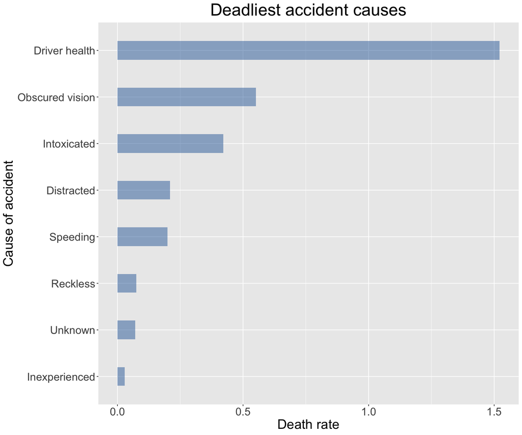

```r
fa_cause %>%
    mutate(cause = fct_reorder(cause, death_rate)) %>%
    ggplot(mapping = aes(x = cause, y = death_rate)) +
    geom_bar(stat = "identity", fill="#326da8", alpha=.5, width=.4) +
    coord_flip() +
    xlab("Cause of accident") +
    ylab("Death rate") +
    ggtitle("Deadliest accident causes") +
    theme(plot.title = element_text(hjust = 0.5, size = 28), axis.text = element_text(size=18),
         axis.title.x = element_text(size=22), axis.title.y = element_text(size=22))
```

## Observations about the graph

Interestingly, it appears that when "driver health" (originally recorded as "physical condition of driver") is the accident cause, the death rate is substantially higher.

## Conclusion for question 4

In our look at fatal accidents we have observed the following through graphs of the 2019 traffic crash data:

- Deadly traffic crashes are spread somewhat evenly throughout the city of Chicago
- Posted speed limit does not appear to have a significant relationship to death rate
- Icy road conditions *is* significantly associated with death rate; the east side of the city is icier, thus deadlier, at least with regard to road conditions
- In terms of crash causes, a driver health issue is associated with the deadliest outcomes

As mentioned, an important caveat applies: we are analyzing only one year of traffic crash data in Chicago. The sample size is limited, so the conclusions are limited by it.

# Conclusion

Overall, there were some conclusions made for each question that were unexpected.

All of our findings present conclusions that can be included as factors into the various accidents around Chicago. Knowing what these factors are, can be used to take action and be preventive in the future to insure the safety of drivers all around Chicago. The findings from this dataset can be correlated to other large citities and help to reduce the number of accidents there.